# Donadeo west entrance to Room ICE 8207

Photo-by-photo directions via the elevators to the eighth floor. Begin at the west entrance of the Donadeo Innovation Centre for Engineering and follow the numbered photos in order.

## 1Find the Donadeo west entrance

Find the west entrance of the Donadeo Innovation Centre for Engineering at 9211 – 116 Street. Look for the building name and Engineering crest beside the recessed glass doors.

[figure not shown]

Photo 1 of 10

## 2Go through the entrance doors

Enter through the glass double doors shown here. An automatic door switch is beside the entrance.

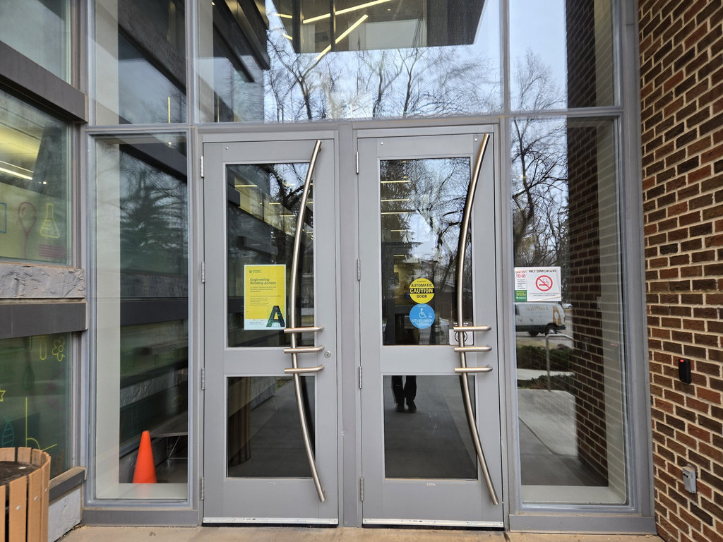

Photo 2 of 10

## 3Follow the sign toward the elevators

Walk along the corridor with the brick wall on your right. At the end, follow the overhead Elevators sign pointing left.

[figure not shown]

Photo 3 of 10

## 4Go through the double automatic doors

Turn left through the double automatic doors beside the washrooms, shown on the left of this photo.

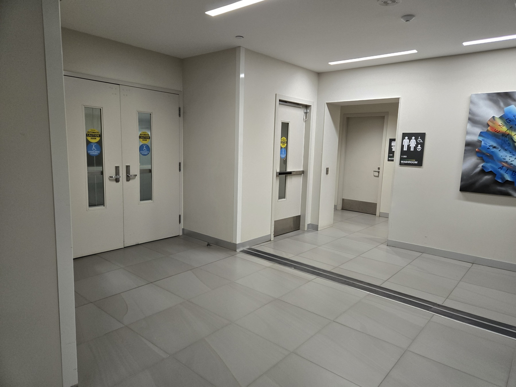

Photo 4 of 10

## 5Continue along the corridor

Walk straight along the corridor, keeping the frosted glass wall on your left. Continue toward the elevator lobby ahead.

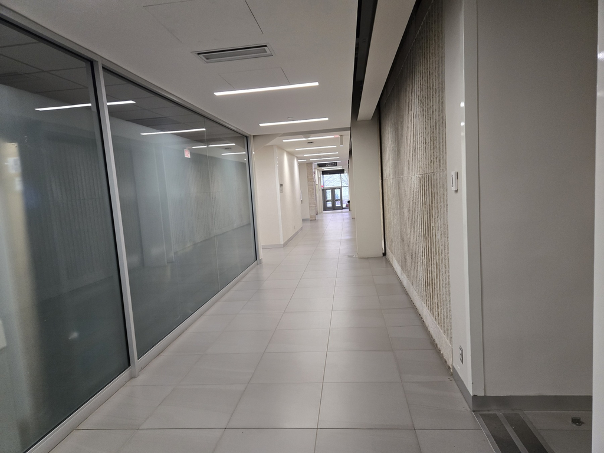

Photo 5 of 10

## 6Take a passenger elevator

Enter the elevator lobby and use the passenger elevators shown on the right. Press the up call button and enter an elevator when it arrives.

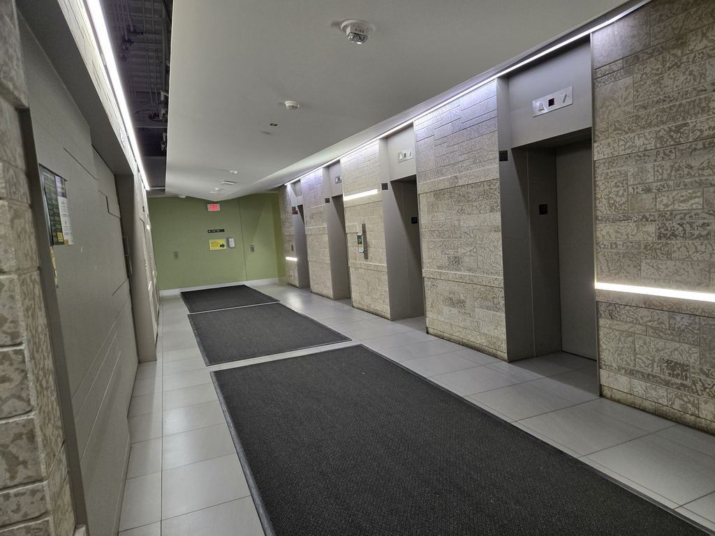

Photo 6 of 10

## 7Press the button for floor 8

Inside the elevator, press 8, as shown by the illuminated button. Take the elevator to the eighth floor and exit when it arrives.

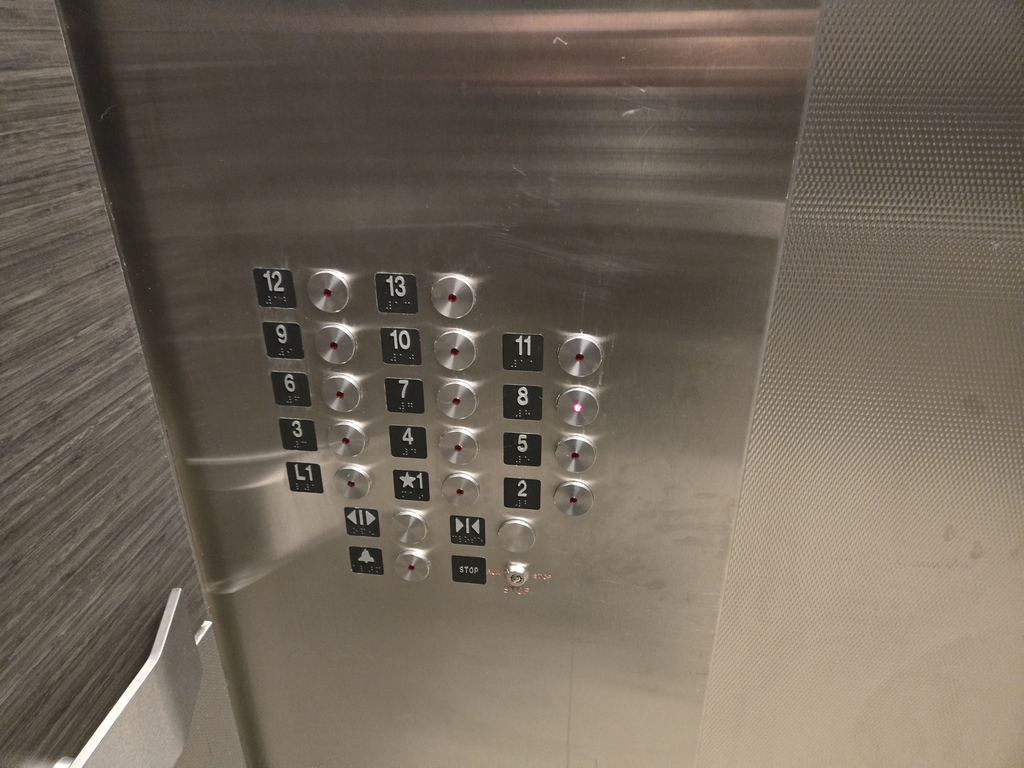

Photo 7 of 10

## 8Head toward the glass doors and turn left

On the eighth floor, go toward the glass doors shown here, then turn left. The wall sign points left toward rooms 8-207 to 8-246 and identifies the Engineering Conference Room 8-207.

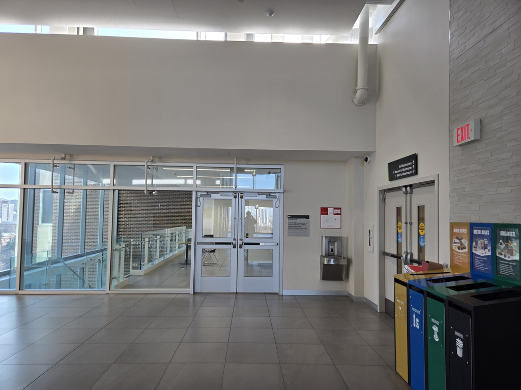

Photo 8 of 10

## 9Find Room 8-207

Look for the wooden double doors with the room plaque 8-207. The sign above reads Patrick D Daniel / Enbridge Engineering Conference Room. This is the workshop room.

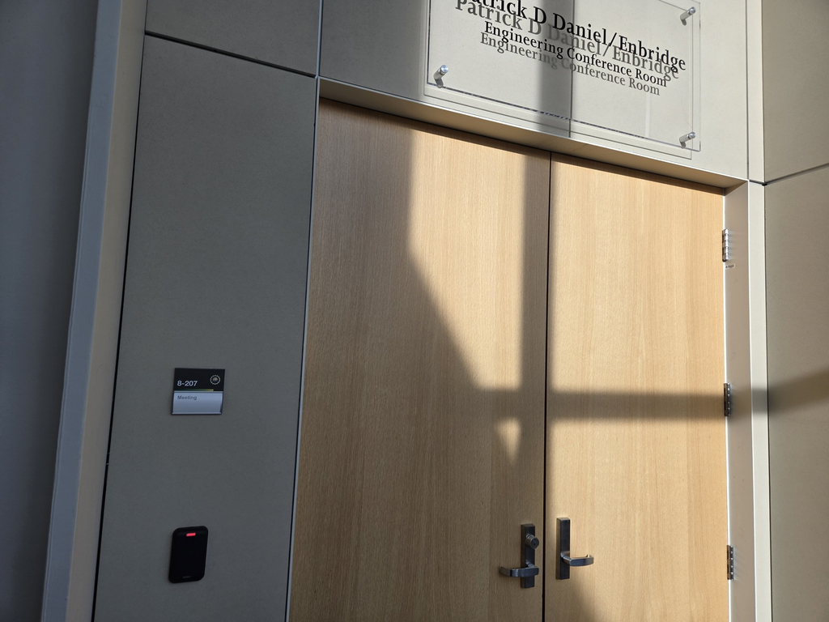

Photo 9 of 10

## 10The second entrance of Room 8207

Room 8207 also has a second entrance along the same corridor. Recognize it by the matching Patrick D Daniel / Enbridge Engineering Conference Room sign and the nearby blue seating.

[figure not shown]

Photo 10 of 10